# IKGeorgakopoulos_03111512_Lab9

## Εθνικό Μετσόβιο Πολυτεχνείο

## Σχολή Ηλεκτρολόγων Μηχανικών & Μηχανικών Υπολογιστών

### Μάθημα: Στοχαστικές διαδικασίες

### Διδάσκων: Μιχαήλ Λουλάκης

### Ακαδημαϊκό έτος: 2017-2018

### Ιωάννης Κ. Γεωργακόπουλος

### Α.Μ.: 03111512

# 9η Εργαστηριακή Άσκηση

Σε αυτό το εργαστήριο θα εργαστούμε πάνω σε ενδιαφέρουσες εφαρμογές των τεχνικών που μάθαμε στο προηγούμενο. Στο τέλος μάλιστα, θα κατασκευάσουμε μία προσεγγιστική λύση του προβλήματος του πλανώδιου πωλητή.

Στα πλαίσια του εργαστηρίου θα χρησιμοποιήσουμε τις παρακάτω βιβλιοθήκες.

```python
import numpy as np
import matplotlib.pyplot as plt

%matplotlib inline
plt.rcParams["figure.figsize"] = (10, 6)  # increase default figure size

np.random.seed(2018)  # for reproducibility
```

## Άσκηση 1: Προσομοιωμένη Ανόπτηση

Στην άσκηση αυτή θα χρησιμοποιήσουμε τη μέθοδο της προσομοιωμένης ανόπτησης ([simulated annealing](https://en.wikipedia.org/wiki/Simulated_annealing)) για να βρουμε το ελάχιστο μιας συνάρτησης $V: \mathbb{R} \to \mathbb{R}$. Εν προκειμένω θα μελετήσουμε την πολυωνυμική συνάρτηση:

$$ V(x) = \frac{13}{90} x^4 - \frac{3}{10} x^3 - \frac{101}{45} x^2 \frac{13}{15}x + 4$$

Η γραφική της παράσταση κατασκευάζεται στο παρακάτω κελί.

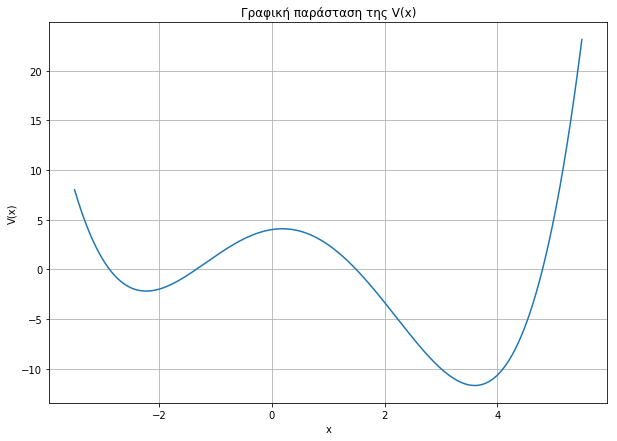

```python
def V(x):
    """Energy (objective) function to minimize"""
    return np.polyval((13/90, -3/10, -101/45, 13/15, 4.0), x)

x = np.linspace(-3.5, 5.5, 1000) #Διαλέγουμε κατάλληλα όρια ώστε να φαίνονται τα ακρότατα της συνάρτησης

plt.figure(figsize = (10, 7))
plt.plot(x, V(x))
plt.xlabel("x")
plt.ylabel("V(x)")
plt.title('Γραφική παράσταση της V(x)')
plt.grid(True)
plt.show()
```

Θα υπολογίσουμε αιτιοκρατικά το τοπικό και ολικό ελάχιστο, ώστε να τα έχουμε ως benchmarks στη συνέχεια.

```python
#np.argmin(V(x))

LocalMin = -2.2293
GlobalMin = 3.60005
```

Ακολουθεί ο αλγόριθμος Metropolis-Hastings για την στοχαστική προσεγγιστική εύρεση των ελαχίστων.

```python
def sim_anneal(f, x_low, x_high,
               T=2.0, T_min=2**(-12),
               cool_factor=0.9, cool_sch=100,
               delta = 1.0, shrink_factor=0.5, shrink_thres=0.25,
               trace = False):

    # Initialize
    x = np.random.uniform(x_low, x_high)
    f_cur = f(x)  # current value of f
    steps = accepted = 0
    if trace: path = []

    # Main loop
    while T > T_min:

        # proposed new position
        x_new = x + np.random.uniform(-delta, delta)
        if x_new > x_high or x_new < x_low:
            continue  # skip this proposal
        f_new = f(x_new)

        # accept/reject jump
        if np.log(np.random.rand()) < -(f_new - f_cur) / T :
            x, f_cur = x_new, f_new
            accepted += 1

        # Cooling
        if steps == cool_sch:  # time for the next cooling
            T *= cool_factor  # cool down
            # Adjust Search Space
            if accepted / steps < shrink_thres:
                delta *= shrink_factor
            steps = accepted = 0

        if trace: path.append(x)
        steps += 1


    if trace: return path
    return x
```

Οι παράμετροι της συνάρτησης `sim_anneal` είναι:

- **`f`**: η συνάρτηση που θέλουμε να ελαχιστοποιήσουμε
- **`x_low, x_high`**: Το όρια μέσα στα οποία ψάχνουμε να βρούμε το ελάχιστο
- **`T, T_min`**: Η αρχική και η τελική θερμοκρασία της "ανόπτησης"
- **`cool_factor`**: Πόσο μειώνεται η θερμοκρασία σε κάθε κύκλο ψύξης (ποσοστό της προηγούμενης)
- **`cool_sch`**: Κάθε πόσα βήματα να μειώνεται η θερμοκρασία
- **`delta`**: Ακτίνα από την οποία θα προτείνουμε άλμα
- **`shrink_factor`**: Πόσο θα μειώσουμε το `delta` αν δούμε ότι η μέθοδος έχει κολλήσει
- **`shirnk_thres`**: Ποσοστό το επιτυχημένων αλμάτων κάτω από το οποίο θεωρούμε ότι το σωματίδιο έχει κολλήσει.
- **`trace`**: Αν θέλουμε να μας γυρίσει όλη την διαδρομή ή μόνο την τελική θέση

Επομένως για να βρούμε το ελάχιστο της συνάρτησης $V$ που ορίσαμε προηγουμένως στο διάστημα $(-3.5, 5.5)$ τρέχουμε την συνάρτηση με τις εξής παραμέτρους.

*Παρατήρηση: Ζητάμε όλο το μονοπάτι του σωματιδίου για να το πλοτάρουμε αργότερα.*

```python
# Parameters
T_start, T_end = 2.0, 2**(-12)
cool_sch, cool_factor = 100, 0.99

path = sim_anneal(V, -3.5, 5.5, delta = 1.,
                  T = T_start, T_min = T_end,
                  cool_factor = cool_factor,
                  cool_sch = cool_sch,
                  trace = True)  # keep the default for the rest, (-3.5,5) ώστε να βρω τα ελάχιστα

path[-1]  # last position
```

```
3.5963735407238038
```

Το επόμενο κελί κώδικα οπτικοποιεί τη διαδικασία. (Σε pop-up window, όπως στο προηγούμενο)

Διαβάζοντας το source code του `animate_simanneal.py`, παρατηρήσαμε ότι το πολυώνυμο με το οποίο μας ζητήθηκε να εργαστούμε, λαμβάνεται αν δόσουμε ως όρισμα -minima 2.

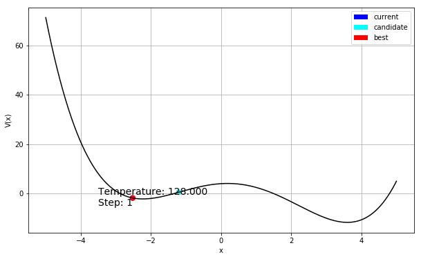

```python
%matplotlib qt
%run ../animate_simanneal.py -minima 2
```

Στη συνέχεια, τρέχουμε το παρακάτω κελί ώστε τα επόμενα διαγράμματα να εμφανίζονται μέσα στο notebook.

```python
%matplotlib inline
```

### Ερώτημα Α)

Θα φτιάξουμε ένα loop με 200 επαναλήψεις και θα συγκρίνουμε την τιμή που βρίσκουμε με τα 2 benchmarks κάθε φορά, ώστε να υπολογίσουμε το ποσοστό.

```python
N = 200 # Αρχικοποίηση επαναλήψεων

N_Local  = 0 # Πλήθος output που βρίσκουν το Local Minima
N_Global = 0 # Πλήθος output που βρίσκουν το Global Minima

for i in range(N):
    path = sim_anneal(V, -3.5, 5, delta = 1.,
                  T = T_start, T_min = T_end,
                  cool_factor = cool_factor,
                  cool_sch = cool_sch,
                  trace = True)  # keep the default for the rest, (-3.5,5) ώστε να βρω τα ελάχιστα

    if abs(path[-1]-LocalMin)<=0.05:
        N_Local  += 1
    if abs(path[-1]-GlobalMin)<=0.05:
        N_Global += 1

print('Ποσοστό εύρεσης κάποιου τοπικού ελαχίστου: ', 100*N_Local/N,'%')
print('Ποσοστό εύρεσης ολικού ελαχίστου:        ', 100*N_Global/N, '%')
```

```
Ποσοστό εύρεσης κάποιου τοπικού ελαχίστου:  0.0 %
Ποσοστό εύρεσης ολικού ελαχίστου:         100.0 %
```

Παρατηρούμε ότι ο αλγόριθμος βρίσκει με εξαιρετικά μεγάλη πιθανότητα το ολικό ελάχιστο. Αυτό συμβαίνει επειδή ο `default cool factor` που έχουμε δώσει είναι μεγάλος.

### Ερώτημα Β)

```python
new_cool_factor = [0.25, 0.5, 0.6, 0.7, 0.8, 0.9, 0.95, 0.99]
Global = np.zeros(len(new_cool_factor), dtype=float)

for j,i in enumerate(new_cool_factor):

    for w in range(N):

        path = sim_anneal(V, -3.5, 5.5, cool_factor= i, trace = True)
        # print(path[-1])

        if abs(path[-1]-GlobalMin)<=0.05:
            Global[j] += 1

print(Global/N)
```

```
[0.705 0.675 0.7   0.7   0.795 0.795 0.92  1.   ]
```

Ακολουθεί ο κώδιξ με το ζητούμενο διάγραμμα.

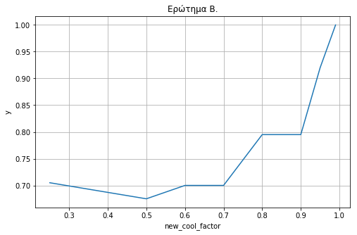

```python
y = Global/N

# Let's plot (x,y)
plt.figure(figsize = (8, 5))
plt.plot(new_cool_factor, y)
# Specify some extra attributes
plt.xlabel('new_cool_factor')
plt.ylabel('y')
plt.title('Ερώτημα Β.')
plt.grid(True)
```

Τα αποτελέσματα είναι ενδιαφέροντα και ταυτόχρονα αναμενόμενα, καθώς δείχνουν ότι όσο αυξάνουμε τον `cool_factor`, τα άλματά μας γίνοται μικρότερα άρα και η αναζήτηση γίνεται πιο αυστηρή οπότε βρίσκουμε με μεγαλύτερη πιθανότητα το σωστό ελάχιστο.

## Άσκηση 2: Πλανόδιος Πωλητής

Στην άσκηση αυτή θα χρησιμοποιήσουμε τον αλγόριθμο της προσομοιωμένης ανόπτησης για να λύσουμε το πρόβλημα του [πλανόδιου πωλητή](https://en.wikipedia.org/wiki/Travelling_salesman_problem).

Το πρόβλημα έχει ως εξής:

> Ένας πωλητής θέλει να επισκεφτεί $Ν$ πόλεις και να γυρίσει στη βάση του. Ποια είναι η συντομότερη διαδρομή που ενώνει όλες τις πόλεις;

Στη συγκεκριμένη άσκηση θα ασχοληθούμε με πόλεις της Ευρώπης. Αρχικά το παρακάτω κελί κώδικα, ώστε να κατεβάσουμε το αρχείο eu.csv που περιέχει το γεωργαφικό μήκος και πλάτος 27 ευρωπαϊκών πόλεων. Ο κώδικας οργανώνει την πληροφορία ως εξής:

- **`city_coord`** ένα `dictionary` που για κάθε πόλη έχει το γεωγραφικό μήκος και πλάτος
- **`Ncities`** ο αριθμός των πόλεων (27)
- **`city_names`** τα ονόματα των πόλεων

Το κελί τυπώνει τις συντεταγμένες της Αθήνας για επαλήθευση.

```python
import csv
import urllib.request

url = "http://math.ntua.gr/~loulakis/info/python_codes_files/eu.csv"
with urllib.request.urlopen(url) as urlstream:
    csvfile = csv.reader(urlstream.read().decode('utf-8').splitlines(), delimiter=",")
    city_coord = {city: tuple(map(float, (longitude, latitude)))
                  for longitude, latitude, city, _ in csvfile}

Ncities = len(city_coord)  # number of cities
city_names = list(city_coord.keys())
city_coord["Athens"]
```

```
(37.97918, 23.716647)
```

Στο επόμενο κελί ορίζουμε την συνάρτηση `geodesic_dist` η οποία υπολογίζει την απόσταση μεταξύ 2 πόλεων δοθέντων των συντεταγμένων τους (credit to [Michael Dunn](http://stackoverflow.com/a/4913653/2167530)) με βάση τον τύπο [Haversine](https://en.wikipedia.org/wiki/Haversine_formula).

```python
def geodesic_dist(city1, city2):
    """
    Calculate the great circle distance between two points
    on the earth (specified in decimal degrees)
    """
    if city1 == city2:
        return 0.
    lon1, lat1 = np.deg2rad(city1)
    lon2, lat2 = np.deg2rad(city2)

    # haversine formula
    dlon = lon2 - lon1
    dlat = lat2 - lat1
    a = np.sin(dlat/2)**2 + np.cos(lat1) * np.cos(lat2) * np.sin(dlon/2)**2
    c = 2 * np.arcsin(np.sqrt(a))
    r = 6371 # Radius of earth in kilometers 6371. Use 3956 for miles
    return c * r
```

Για ευκολία και ταχύτητα θα υπολογίσουμε όλες τις αποστάσεις εκ των προτέρων και θα τις αποθηκεύσουμε σε ένα πίνακα

```python
# Distance between every pair of cities
dist = np.array([
    [geodesic_dist(coord1, coord2) for coord2 in city_coord.values()]
    for coord1 in city_coord.values()
])
```

Σαν σύμβαση θεωρούμε ότι η αρχική σειρά των πόλεων είναι αυτή με την οποία μπορούμε να κάνουμε iterate το `city_coord` δηλαδή:

```python
for i, city in enumerate(city_coord): print(i, city)
```

```
0 Brussels
1 Vienna
2 Sofia
3 Nicosia
4 Prague
5 Copenhagen
6 London
7 Helsinki
8 Paris
9 Berlin
10 Athens
11 Budapest
12 Reykjavik
13 Rome
14 Riga
15 Luxembourg
16 Monaco
17 Amsterdam
18 Oslo
19 Warsaw
20 Lisbon
21 Bucharest
22 Moscow
23 Edinburgh
24 Belgrade
25 Madrid
26 Stockholm
```

### Αλγόριθμος

Επειδή ο δρόμος που θα ακολουθήσει ο πωλητής είναι κυκλικός, δεν έχει σημασία από που θα ξεκινήσει (μόνο ποιες πόλεις θέλει να επισκεφθεί έχει σημασία). Ως εκ τούτου, "λύση" στο πρόβλημα μας είναι μια λίστα με τη σειρά με την οποία κάποιος πρέπει να επισκεφθεί τις πόλεις, δεδομένου ότι μετά την τελευταία πόλη θα επιστρέψει στην αρχική χωρίς να επισκεφθεί άλλη πόλη.

Επομένως, σκοπός μας είναι να χρησιμοποιήσουμε την τεχνική της προσομοιωμένης ανόπτησης για να "ψάξουμε" τον χώρο των μεταθέσεων της λίστας των πόλεων ώστε να βρούμε την μετάθεση που δίνει την συνολική απόσταση κοντά στην ελάχιστη δυνατή.

Για να τρέξουμε τον αλγόριθμο της ανόπτησης χρειαζόμαστε 2 στοιχεία:

1. Μια συνάρτηση *ενέργειας*
2. Έναν τρόπο να μεταβαίνουμε σε γειτονικές καταστάσεις

Ως συνάρτηση ενέργειας θα πάρουμε την συνολική απόσταση που διανύει ο πωλητής (αυτή που θέλουμε να ελαχιστοποιήσουμε). Στο παρακάτω κελί ορίζουμε την συνάρτηση (είσοδος η σειρά με την οποία ο πωλητής επισκέπτεται τις πόλεις):

```python
def total_dist(cities):
    """The total distance covered by the salesman"""
    total = sum(dist[city1][city2] for city1, city2 in zip(cities[:-1], cities[1:]))
    total += dist[cities[-1]][cities[0]] # return to start
    return total
```

Ως γειτονικές μεταθέσεις, ορίζουμε τις μεταθέσεις που διαφέρουν μόνο σε ένα ζευγάρι πόλεων. Επομένως για να κινηθούμε στον χώρο το μεταθέσεων, θα διαλέγουμε τυχαία 2 πόλεις και θα αλλάζουμε τη θέση τους στη λίστα.

Για να υπολογίσουμε την αλλαγή στην συνολική απόσταση για μια τέτοια αλλαγή, μπορούμε να προσθέσουμε όλες τις αποστασεις από την αρχή αλλά προφανώς κάτι τέτοιο δεν είναι αποδοτικό. Γι' αυτό το λόγο ορίζουμε την συνάρτηση `dist_diff`. Στην επόμενη ενότητα εξηγούμε την λογική της συνάρτησης, αν δεν την καταλαβαίνετε μπορείτε απλά να την χρησιμοποιήσετε σαν μαύρο κουτί.

### Κόστος αλλαγής σειράς επίσκεψης

Η αλλαγή της σειράς 2 πόλεων είναι μια τοπική αλλαγή επομένως αρκεί να σκεφτούμε ποιές είναι συνέπειες αυτές της αλλαγής. *Πόσες αποστάσεις επηρεάζονται συνολικά;*

Θεωρείστε 2 τριάδες πόλεων τυχαία μέσα στη λίστα:

- $A \to B \to C$ και
- $X \to Y \to Z$

και και χωρίς βλάβη στη γενικότητα θεωρείστε ότι η πόλη $B$ εμφανίζεται πριν από την $Y$ στη λίστα.

Υπάρχουν 2 περιπτώσεις

1. Γενική περίπτωση $B$ και $Y$ δεν συνορεύουν (δηλαδή $X \not\equiv B$)
2. Ειδική περιπτωση $B$ και $Y$ συνορεύουν (δηλαδή $X \equiv B$)

Στο παρακάτω διάγραμμα φαίνονται οι συνέπειες που θα είχε μια αλλαγή μεταξύ $B$ και $Y$ στις 2 αυτές περιπτώσεις.

[figure not shown]

Στο παρακάτω κελί ορίζουμε την συνάρτηση.

```python
def dist_diff(ABC, XYZ, tour):
    """
    Differnce of total distance traveled if we swap cities B, Y.
    Input: 2 triplets of nodes A, B, C and X, Y, Z.
    """
    # order
    A, B, C = ABC
    X, Y, Z = XYZ
    # cities
    a, b, c = tour[ABC]
    x, y, z = tour[XYZ]

    BpY = (B - Y) % len(tour) # to understand the order
    dx = 0

    if BpY != -1 % len(tour):  #  B is not X
        dx += dist[x, b] - dist[x, y] + dist[y, c] - dist[b, c]
    if BpY != 1:  # Y is not A
        dx += dist[a, y] - dist[a, b] + dist[b, z] - dist[y, z]

    return dx
```

### Υλοποίηση

Στο παρακάτω κελί υλοποιούμε τον αλγόριθμο της προσομοιωμένης ανόπτησης για το πρόβλημα το πλανόδιου πωλητή.

Αρχικά θέτουμε τις παραμέτρους του αλγορίθμου και μερικές μεταβλητές γαι να οπτικοποιήσουμε τα αποτελέσματα. Ο κώδικας είναι σχεδόν ίδιος με την συνάρτηση που δόθηκε προηγουμένως. Μια σημαντική διαφορά είναι ότι τώρα αποθηκεύουμε τη βέλτιστη λύση που έχουμε βρει μέχρι κάθε στιγμή. Αυτό το κάνουμε γιατί με μικρό υπολογιστικό κόστος μπορεί να βρούμε μια καλύτερη διαδρομή την οποία ο αλγόριθμος εξερεύνησε στην πορεία αλλά δεν τερμάτισε σε αυτήν.

```python
# Annealing Parameters
Temp = 10 ** 7
Temp_end = 0.02
cool_factor = 0.95
cool_schedule = 100

# Bookeeping parameters
tour = np.arange(Ncities)  # initial permutation
tour_length = total_dist(tour)  # initial energy level

shortest_tour = np.copy(tour)  # optimal permutation (to be updated)
shortest_tour_length = tour_length  # shortest distance

# To plot later
first_guess = tour_length
running_lengths = []
optimal_lengths = []

# Main loop
while Temp > Temp_end:
    # Constant Temperature Era
    for step in range(cool_schedule):
        # Choose 2 cities to swap
        B, Y = np.random.choice(Ncities, size=2, replace=False)  # index of cities to swap
        ABC = np.array([B-1, B, B+1]) % Ncities  # neighbors of B
        XYZ = np.array([Y-1, Y, Y+1]) % Ncities  # neighbors of Y

        # Compute the energy diffence
        diff = dist_diff(ABC, XYZ, tour)

        # Decide whether to change state.
        if np.log(np.random.rand()) < -diff / Temp:
            tour[B], tour[Y] = tour[Y], tour[B]
            tour_length += diff
            # Keep track of the optimal tour observed
            if tour_length < shortest_tour_length:
                shortest_tour = np.copy(tour)
                shortest_tour_length = tour_length

        running_lengths.append(tour_length)
        optimal_lengths.append(shortest_tour_length)

    Temp *= cool_factor  # cool down

print('Improvement:\t%8.0f%%'  % (100 * (first_guess - shortest_tour_length) / first_guess))
print('Initial distance:\t%.0f km'  % first_guess)
print('Optimal distance:\t%.0f km'  % shortest_tour_length)
```

```
Improvement:	      63%
Initial distance:	60608 km
Optimal distance:	22637 km
```

### Αποτελέσματα

Παρακάτω πλοτάρουμε την εξέλιξη της τρέχουσας βέλτιστης λύσης κατά την διάρκεια του αλγορίθμου.

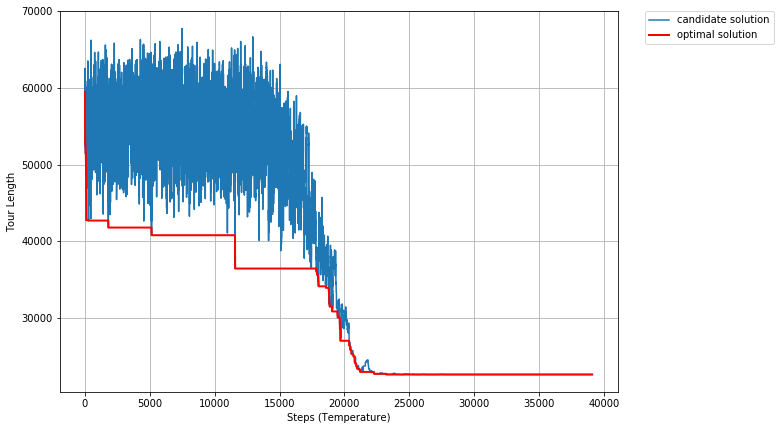

```python
running_lengths = np.array(running_lengths)
optimal_lengths = np.array(optimal_lengths)

plt.figure(figsize = (10, 7))
plt.plot(np.arange(len(running_lengths)), running_lengths, label="candidate solution")
plt.plot(np.arange(len(optimal_lengths)), optimal_lengths, 'r-', linewidth=2, label="optimal solution")

plt.xlabel("Steps (Temperature)")
plt.ylabel("Tour Length")
plt.legend(bbox_to_anchor=(1.05, 1), loc=2, borderaxespad=0.)
plt.grid()

plt.show()
```

Τέλος, με το επόμενο κελί κώδικα δημιουργούμε μια οπτική αναπαράσταση της βέλτιστης διαδρομής.

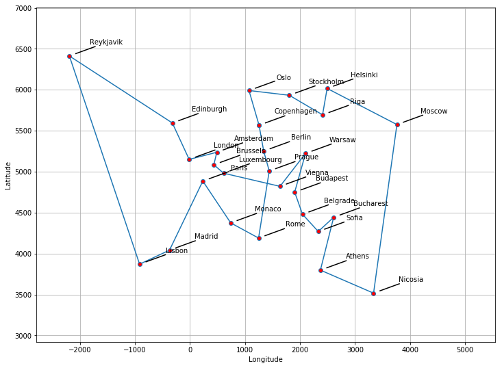

```python
plt.figure(figsize=(12, 9))  # increase image size

# Get Tour Coordinates
coord = np.array([city_coord[city] for city in city_names])
cities = shortest_tour.copy()
cities = np.append(cities, cities[0])
coord = coord[cities,:]  # rearrange

# Scale for better readability
scale_factor = 100
coord = coord * scale_factor

# Plot Tour
plt.plot(coord[:, 1], coord[:,0], 'o-', mfc='r')
plt.xlabel("Longitude")
plt.ylabel("Latitude")
plt.grid()

# Manage spacing
spacing = np.fabs(min(coord[:,1]) - max(coord[:,1])) * .1
plt.xlim(min(coord[:,1]) - spacing, max(coord[:,1]) + spacing * 3)
plt.ylim(min(coord[:,0]) - spacing, max(coord[:,0]) + spacing)

# Add labels - remove for more clear picture
if len(cities)<=30:
    for i, city in enumerate(cities[:-1]):
        plt.text(coord[i,1], coord[i,0],
                 '%s' % city_names[city],
                 withdash = True,
                 dashdirection = 1,
                 dashlength = 30,
                 rotation = 0,
                 dashrotation = 20,
                 dashpush = 10)
plt.show()
```

### Ερώτημα Α)

Θα προσπαθήσουμε να βελτιώσουμε την λύση πειράζοντας τις παραμέτρους του κώδικα.

Αρχικά θα μετατρέψουμε κομμάτια κώδικα σε συναρτήσεις ώστε να τα χρησιμοποιήσουμε και μετά.

Στο παρακάτω μετασχηματίζουμε το κομμάτι κώδικα που μας δόθηκε ώστε να κατασκευάσουμε μία συνάρτηση που θα εμφανίζει το μήνυμα βελτίωσης, το γράφημα της εξέλιξης της τρέχουσας βέλτιστης λύσης κατά την διάρκεια του αλγορίθμου καθώς και μια οπτική αναπαράσταση της βέλτιστης διαδρομής. Επιλέξαμε να επιστρέφει το `shortest_tour`.

```python
def tsp_sim_anneal(city_coord, Temp, Temp_end, cool_factor, cool_schedule):

    Ncities = len(city_coord)  # number of cities
    city_names = list(city_coord.keys())

    # Bookeeping parameters
    tour = np.arange(Ncities)  # initial permutation
    tour_length = total_dist(tour)  # initial energy level

    shortest_tour = np.copy(tour)  # optimal permutation (to be updated)
    shortest_tour_length = tour_length  # shortest distance

    # To plot later
    first_guess = tour_length
    running_lengths = []
    optimal_lengths = []

    # Main loop
    while Temp > Temp_end:
        # Constant Temperature Era
        for step in range(cool_schedule):
            # Choose 2 cities to swap
            B, Y = np.random.choice(Ncities, size=2, replace=False)  # index of cities to swap
            ABC = np.array([B-1, B, B+1]) % Ncities  # neighbors of B
            XYZ = np.array([Y-1, Y, Y+1]) % Ncities  # neighbors of Y

            # Compute the energy diffence
            diff = dist_diff(ABC, XYZ, tour)

            # Decide whether to change state.
            if np.log(np.random.rand()) < -diff / Temp:
                tour[B], tour[Y] = tour[Y], tour[B]
                tour_length += diff
                # Keep track of the optimal tour observed
                if tour_length < shortest_tour_length:
                    shortest_tour = np.copy(tour)
                    shortest_tour_length = tour_length

            running_lengths.append(tour_length)
            optimal_lengths.append(shortest_tour_length)

        Temp *= cool_factor  # cool down

    print('Improvement:\t%8.0f%%'  % (100 * (first_guess - shortest_tour_length) / first_guess))
    print('Initial distance:\t%.0f km'  % first_guess)
    print('Optimal distance:\t%.0f km'  % shortest_tour_length)

    #plotting running - optimal lengths
    running_lengths = np.array(running_lengths)
    optimal_lengths = np.array(optimal_lengths)

    plt.figure(figsize = (10, 7))
    plt.plot(np.arange(len(running_lengths)), running_lengths, label="candidate solution")
    plt.plot(np.arange(len(optimal_lengths)), optimal_lengths, 'r-', linewidth=2, label="optimal solution")

    plt.xlabel("Steps (Temperature)")
    plt.ylabel("Tour Length")
    plt.legend(bbox_to_anchor=(1.05, 1), loc=2, borderaxespad=0.)
    plt.grid()

    plt.show()

    #plot city tour map
    plt.figure(figsize=(12, 9))  # increase image size

    # Get Tour Coordinates
    coord = np.array([city_coord[city] for city in city_names])
    cities = shortest_tour.copy()
    cities = np.append(cities, cities[0])
    coord = coord[cities,:]  # rearrange

    # Scale for better readability
    scale_factor = 100
    coord = coord * scale_factor

    # Plot Tour
    plt.plot(coord[:, 1], coord[:,0], 'o-', mfc='r')
    plt.xlabel("Longitude")
    plt.ylabel("Latitude")
    plt.grid()

    # Manage spacing
    spacing = np.fabs(min(coord[:,1]) - max(coord[:,1])) * .1
    plt.xlim(min(coord[:,1]) - spacing, max(coord[:,1]) + spacing * 3)
    plt.ylim(min(coord[:,0]) - spacing, max(coord[:,0]) + spacing)

    # Add labels - remove for more clear picture
    if len(cities)<=30:
        for i, city in enumerate(cities[:-1]):
            plt.text(coord[i,1], coord[i,0],
                     '%s' % city_names[city],
                     withdash = True,
                     dashdirection = 1,
                     dashlength = 30,
                     rotation = 0,
                     dashrotation = 20,
                     dashpush = 10)
    plt.show()

    return shortest_tour
```

Στη συνέχεια τρέχουμε την συνάρτηση με διαφορετικές παραμέτρους, ώστε να βγάλουμε καλύτερα αποτελέσματα.

```
Improvement:	      61%
Initial distance:	60608 km
Optimal distance:	23742 km
```

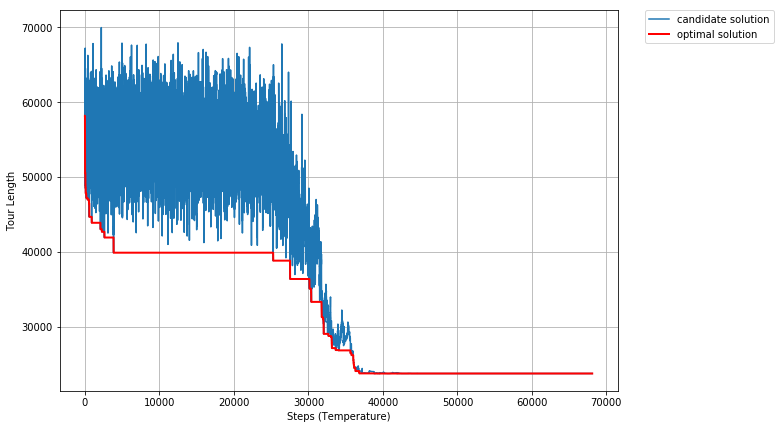

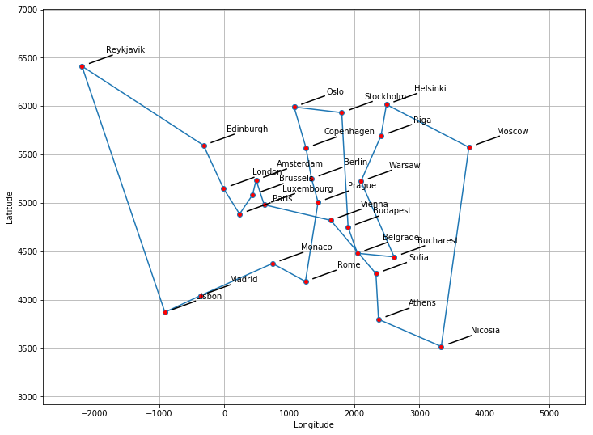

```
array([18,  5,  9,  4, 13, 16, 25, 20, 12, 23,  6,  8,  0, 17, 15,  1,  2,
       10,  3, 22,  7, 14, 19, 21, 24, 11, 26])
```

```python
# Annealing Parameters
Temp = 10 ** 7
Temp_end = 0.01
cool_factor = 0.97
cool_schedule = 100

tsp_sim_anneal(city_coord, Temp, Temp_end, cool_factor, cool_schedule)
```

```
Improvement:	      63%
Initial distance:	60608 km
Optimal distance:	22579 km
```

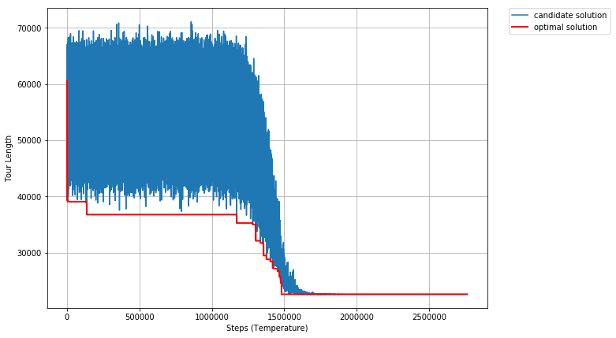

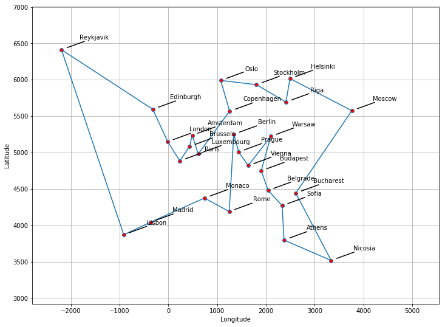

```
array([ 2, 24, 11, 19,  1,  4,  9, 13, 16, 25, 20, 12, 23,  6,  8,  0, 17,
       15,  5, 18, 26, 14,  7, 22, 21,  3, 10])
```

```python
# Annealing Parameters
Temp = 10 ** 9
Temp_end = 0.001
cool_factor = 0.999
cool_schedule = 100

tsp_sim_anneal(city_coord, Temp, Temp_end, cool_factor, cool_schedule)
```

Βελτιώθηκε περαιτέρω (κατά 2% επί της προηγούμενης), και δεν παρατηρούμε διασταυρώσεις.

Τσεκάρουμε αν έχουμε δυναμική εμβέλεια για ορισμό του `dist` εντός της συνάρτησης για το επόμενο ερώτημα. Θα μπορούσα να το είχα γκουγκλάρει, αλλά δεν είχα internet.

```python
malakas = "patrick"

def lul2():
    print(POGGERS)
    return

def lul():
    POGGERS = "bob"
    print(POGGERS)
    lul2()
    return

lul()
```

[output not shown]

Επαληθεύσαμε στατική εμβέλεια, άρα δεν μπορούμε να ορίσουμε νέο dist μες το `tsp_sim_anneal()`, διότι ορίζεται ως `local` και όταν ζητείται από επόμενες συναρτήσεις εκτός του `block`, λαμβάνεται το `global` που έχει οριστεί πιο πάνω. Οπότε, Θα το ανανεόνουμε εκτός, μετά από εκάστοτε `city_cοord`. (Εναλλακτικά θα μπορούσαμε να πειράξουμε αναλόγως τις δοθείσες συναρτήσεις).

### Ερώτημα Β)

Τα δεδομένα είναι σε αυτή τη διεύθυνση

http://math.ntua.gr/~loulakis/info/python_codes_files/europe.csv

Αρχικά επικαιροποιούμε το `dictionary`:

```python
url = "http://math.ntua.gr/~loulakis/info/python_codes_files/europe.csv"
with urllib.request.urlopen(url) as urlstream:
    csvfile = csv.reader(urlstream.read().decode('utf-8').splitlines(), delimiter=",")
    city_coord = {city: tuple(map(float, (longitude, latitude)))
                  for longitude, latitude, city, _ in csvfile}

Ncities = len(city_coord)  # number of cities
city_names = list(city_coord.keys())
city_coord["Athens"] # check dictionary
```

```
(37.97918, 23.716647)
```

Και το `dist` (Πίνακας με όλες τις αποστάσεις μεταξύ δοθέντων πόλεων).

```python
# Distance between every pair of cities
dist = np.array([
    [geodesic_dist(coord1, coord2) for coord2 in city_coord.values()]
    for coord1 in city_coord.values()
])
```

Και ξανατρέχουμε τη συνάρτηση `tsp_sim_anneal()`, με τις κατάλληλες παραμέτρους

```
Improvement:	      70%
Initial distance:	100118 km
Optimal distance:	29678 km
```

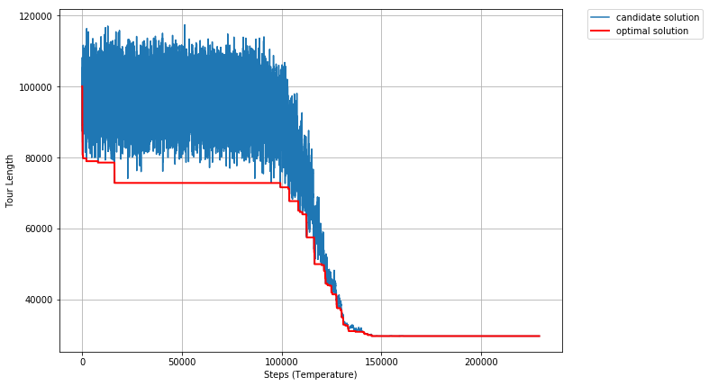

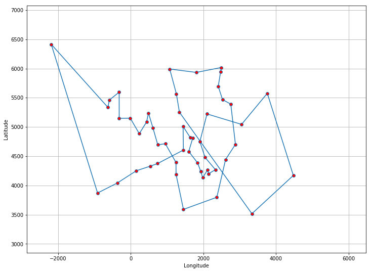

```
array([32,  5,  7, 43,  3,  9, 44, 31, 15,  2, 45, 37, 20, 21, 34, 41, 49,
       11, 14,  0, 33, 27, 47, 25, 40, 22, 29, 18, 38, 30,  4, 26, 24, 12,
       13, 46, 35, 10, 17,  8, 16, 39, 48, 36, 19, 42,  6, 28, 23,  1])
```

```python
# Annealing Parameters
Temp = 10 ** 8
Temp_end = 0.01
cool_factor = 0.99
cool_schedule = 100

tsp_sim_anneal(city_coord, Temp, Temp_end, cool_factor, cool_schedule)
```

Βλέπουμε πολλαπλές διασταύρωσεις, οπότε μπορεί να βελτιωθεί σίγουρα. Ας το ξανατρέξουμε με πιο εξαντλητικές παραμέτρους.

```
Improvement:	      72%
Initial distance:	100118 km
Optimal distance:	28068 km
```

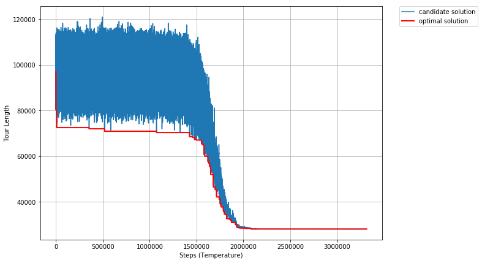

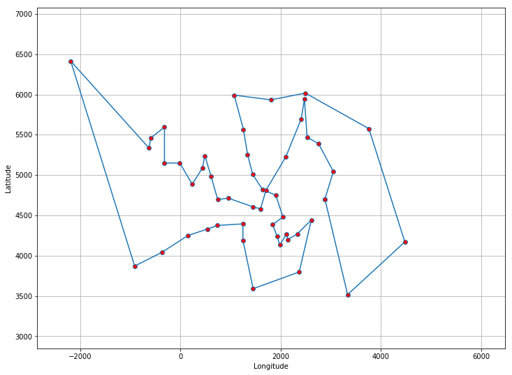

```
array([30, 48,  4, 26, 12, 24, 36, 43,  7, 44, 25, 47, 27, 33,  0, 14, 11,
       49, 41, 34, 21, 20, 37, 45,  2, 15, 31, 40, 22, 29, 18, 38,  6, 28,
       23,  1, 32,  5, 42, 19,  3,  9, 17, 10, 35, 46, 13, 39, 16,  8])
```

```python
# Annealing Parameters
Temp = 10 ** 9
Temp_end = 0.001
cool_factor = 0.999
cool_schedule = 120

tsp_sim_anneal(city_coord, Temp, Temp_end, cool_factor, cool_schedule)
```

Βελτιώθηκε κατά 2% επί της προηγούμενης, χωρίς εμφανείς διασταυρώσεις.

### Ερώτημα Γ)

#### 2. Αν σε έναν υπολογιστή ο χρόνος που απαιτείται για τον υπολογισμό του συνολικού μήκους ενός τέτοιου μονοπατιού ήταν 1μsec, πόσο χρόνο θα χρειαζόμασταν για να βρούμε το βέλτιστο μονοπάτι με έναν εξαντλητικό αλγόριθμο (brute force) που θα υπολόγιζε τη συνολική απόσταση που θα διανύσει ο πλανόδιος πωλητής κατά μήκος κάθε μονοπατιού και θα επέστρεφε το μονοπάτι με την ελάχιστη συνολική απόσταση;

```python
import math

secs = math.factorial(34) * 10**(-6)
mins = secs/60
hours = mins/60
days = hours/24
weeks = days/7
years = weeks/52

b_yrs = years/(10**(9))

print("Brute force: {} seconds".format(int(secs)))
print("For context: {} billion years".format(int(b_yrs)))
```

```
Brute force: 295232799039604140593661287071744 seconds
For context: 9387489794452208 billion years
```